# Importing all required libraries

```python
import os
import requests
import json
cwd = os.getcwd()
```

```python
import matplotlib.pyplot as plt
from matplotlib import rcParams
import matplotlib as mpl
import seaborn as sb
import numpy as np
import pandas as pd
from pandas import Series
import zipfile
from bs4 import BeautifulSoup
import re
from IPython.display import Image
from IPython.core.display import HTML
from pandas import DataFrame, Panel

%matplotlib inline
%config InlineBackend.figure_format = 'retina'
rcParams['figure.figsize'] = 10, 10
sb.set_style('whitegrid')


pd.set_option('display.height', 1000)
pd.set_option('display.max_rows', 1000)
pd.set_option('display.max_columns', 500)
pd.set_option('display.width', 1000)

pd.set_option('display.max_rows',15) # this limit maximum numbers of rows
```

# Gathering Data

## Getting the Twitter Archive

```python
df = pd.read_csv('twitter-archive-enhanced.csv')
df.info()
```

```
<class 'pandas.core.frame.DataFrame'>
RangeIndex: 2356 entries, 0 to 2355
Data columns (total 17 columns):
tweet_id                      2356 non-null int64
in_reply_to_status_id         78 non-null float64
in_reply_to_user_id           78 non-null float64
timestamp                     2356 non-null object
source                        2356 non-null object
text                          2356 non-null object
retweeted_status_id           181 non-null float64
retweeted_status_user_id      181 non-null float64
retweeted_status_timestamp    181 non-null object
expanded_urls                 2297 non-null object
rating_numerator              2356 non-null int64
rating_denominator            2356 non-null int64
name                          2356 non-null object
doggo                         2356 non-null object
floofer                       2356 non-null object
pupper                        2356 non-null object
puppo                         2356 non-null object
dtypes: float64(4), int64(3), object(10)
memory usage: 313.0+ KB
```

## Getting the extra data from Twitter API

```python
import tweepy

consumer_key = ''
consumer_secret = ''
access_token = ''
access_secret = ""

auth = tweepy.OAuthHandler(consumer_key, consumer_secret)
auth.set_access_token(access_token, access_secret)

api = tweepy.API(auth, wait_on_rate_limit = True, wait_on_rate_limit_notify = True)
```

### Writing a JSON file storing all the tweets

```python
tweet = []
tweet_dict = {"tweet_id" :[], "tweet_status" :[],
              "full_text" :[], "retweet_count": [], "favorite_count" : []}
for ids in enumerate(df.tweet_id):
    try:
        status = api.get_status(ids[1], tweet_mode='extended')

        tweet.append(status)
        tweet_dict["tweet_status"].append(status)
        tweet_dict["tweet_id"].append(status.id)
        tweet_dict["full_text"].append(status.full_text)
        tweet_dict["retweet_count"].append(status.retweet_count)
        tweet_dict["favorite_count"].append(status.favorite_count)
    except:
        pass
```

### converting the created doctionary into a Pandas DataFrame

```python
tweet_df = pd.DataFrame.from_dict(tweet_dict );
```

#### Storing the Data Frame into a CSV file

```python
tweet_df.to_csv('tweet_df.csv')
```

### Writing the Tweet Statuses into a txt file:

```python
pd.DataFrame(tweet).to_csv(r'tweet_json.txt', header=None, index=None, sep=' ', mode='a')
```

### Reading the JSON data from the "tweet_json.txt" into a DataFrame

```python
json_df = pd.read_csv('tweet_json.txt', header = None)
```

## Downloading the TSV file Programmatically

```python
url = "https://d17h27t6h515a5.cloudfront.net/topher/2017/August/599fd2ad_image-predictions/image-predictions.tsv"

response = requests.get(url)
with open("image_predictions.tsv", mode='wb') as file:
        file.write(response.content)
```

### Reading the TSV file into a DataFrame

```python
df_immage = pd.read_csv('image_predictions.tsv', sep = '\t')
df_immage.info()
```

```
<class 'pandas.core.frame.DataFrame'>
RangeIndex: 2075 entries, 0 to 2074
Data columns (total 12 columns):
tweet_id    2075 non-null int64
jpg_url     2075 non-null object
img_num     2075 non-null int64
p1          2075 non-null object
p1_conf     2075 non-null float64
p1_dog      2075 non-null bool
p2          2075 non-null object
p2_conf     2075 non-null float64
p2_dog      2075 non-null bool
p3          2075 non-null object
p3_conf     2075 non-null float64
p3_dog      2075 non-null bool
dtypes: bool(3), float64(3), int64(2), object(4)
memory usage: 152.1+ KB
```

# Assessing Data

## Assessing the Twitter Archive

```python
df = pd.read_csv('twitter-archive-enhanced.csv')
df.info()
```

```
<class 'pandas.core.frame.DataFrame'>
RangeIndex: 2356 entries, 0 to 2355
Data columns (total 17 columns):
tweet_id                      2356 non-null int64
in_reply_to_status_id         78 non-null float64
in_reply_to_user_id           78 non-null float64
timestamp                     2356 non-null object
source                        2356 non-null object
text                          2356 non-null object
retweeted_status_id           181 non-null float64
retweeted_status_user_id      181 non-null float64
retweeted_status_timestamp    181 non-null object
expanded_urls                 2297 non-null object
rating_numerator              2356 non-null int64
rating_denominator            2356 non-null int64
name                          2356 non-null object
doggo                         2356 non-null object
floofer                       2356 non-null object
pupper                        2356 non-null object
puppo                         2356 non-null object
dtypes: float64(4), int64(3), object(10)
memory usage: 313.0+ KB
```

## Issues within the Tweeter Archive DataFrame:

`Tidiness Issues`

- T-1 **denominator of 10 and the numerators could all be in one column**
- T-2 **dog stages need to be in one single column (doggo, floofer, pupper, puppo)**
- T-3 **it's not clear if the tweet is the original satus or a retweet of something else, so we need to add a column for Retweet (Yes/No)**

`Quality Issues`

- Q-1 **too many NaNs in (in_reply_to_status_id, in_reply_to_user_id, retweeted_status_id, retweeted_status_user_id, retweeted_status_timestamp)**
- Q-2 **source column is not clear and we need to extract the exact source like iPhone, etc.**
- Q-3 **for Dos Stage and Name, for missing values, "None" is used rather than NaN**
- Q-4 **timestamp is not standard, so we could change it to a standard format of Date-time**
- Q-7 **after replacing None with NaN, we see that a lot of Dog Stages are missing!**
- Q-9 **All other ID fileds are also need to be converted into String like `in_reply_to_status_id`**
- Q-10 **It appears that we have inconsistency in extracting the ratings (the numinators). Sometimes the digits after decimal point is extracted**

## Assessing the Image Prediction DataFrame

```python
df_image = pd.read_csv('image_predictions.tsv', sep = '\t')
df_image.info()
```

```
<class 'pandas.core.frame.DataFrame'>
RangeIndex: 2075 entries, 0 to 2074
Data columns (total 12 columns):
tweet_id    2075 non-null int64
jpg_url     2075 non-null object
img_num     2075 non-null int64
p1          2075 non-null object
p1_conf     2075 non-null float64
p1_dog      2075 non-null bool
p2          2075 non-null object
p2_conf     2075 non-null float64
p2_dog      2075 non-null bool
p3          2075 non-null object
p3_conf     2075 non-null float64
p3_dog      2075 non-null bool
dtypes: bool(3), float64(3), int64(2), object(4)
memory usage: 152.1+ KB
```

```python
df_image.sample(10)
```

|  | tweet_id | jpg_url | img_num | p1 | p1_conf | p1_dog | p2 | p2_conf | p2_dog | p3 | p3_conf | p3_dog |
| --- | --- | --- | --- | --- | --- | --- | --- | --- | --- | --- | --- | --- |
| 1736 | 821813639212650496 | https://pbs.twimg.com/media/CtVAvX-WIAAcGTf.jpg | 1 | Saint_Bernard | 0.995143 | True | Cardigan | 0.003044 | True | English_springer | 0.001050 | True |
| 139 | 668542336805281792 | https://pbs.twimg.com/media/CUcjtL8WUAAAJoz.jpg | 1 | American_Staffordshire_terrier | 0.267695 | True | French_bulldog | 0.254050 | True | Staffordshire_bullterrier | 0.212381 | True |
| 702 | 684902183876321280 | https://pbs.twimg.com/media/CYFC5lmWAAAEIho.jpg | 1 | Pembroke | 0.708034 | True | Cardigan | 0.291447 | True | dingo | 0.000185 | False |
| 2062 | 889665388333682689 | https://pbs.twimg.com/media/DFi579UWsAAatzw.jpg | 1 | Pembroke | 0.966327 | True | Cardigan | 0.027356 | True | basenji | 0.004633 | True |
| 1309 | 754011816964026368 | https://pbs.twimg.com/media/CnbJuPoXEAAjcVF.jpg | 1 | French_bulldog | 0.600985 | True | Boston_bull | 0.273176 | True | boxer | 0.056772 | True |
| 750 | 687826841265172480 | https://pbs.twimg.com/media/CYum3KbWEAArFrI.jpg | 1 | Pomeranian | 0.997210 | True | Pekinese | 0.000803 | True | keeshond | 0.000373 | True |
| 1074 | 717009362452090881 | https://pbs.twimg.com/media/CfNUNetW8AAekHx.jpg | 1 | Siberian_husky | 0.506154 | True | Eskimo_dog | 0.269656 | True | malamute | 0.060658 | True |
| 1503 | 784826020293709826 | https://pbs.twimg.com/media/CuRDF-XWcAIZSer.jpg | 1 | chow | 0.090341 | True | binoculars | 0.083499 | False | Irish_setter | 0.077456 | True |
| 732 | 686730991906516992 | https://pbs.twimg.com/media/CYfCMdFWAAA44YA.jpg | 1 | Tibetan_mastiff | 0.338812 | True | Newfoundland | 0.180925 | True | golden_retriever | 0.180023 | True |
| 1398 | 768473857036525572 | https://pbs.twimg.com/media/Cqoq5PGWAAA-U8T.jpg | 1 | Labrador_retriever | 0.739170 | True | Chesapeake_Bay_retriever | 0.246488 | True | kelpie | 0.006892 | True |

```python
df_image.p1.value_counts()
```

```
golden_retriever      150
Labrador_retriever    100
Pembroke               89
Chihuahua              83
pug                    57
chow                   44
Samoyed                43
                     ...
polecat                 1
cheetah                 1
hand_blower             1
coho                    1
grey_fox                1
conch                   1
skunk                   1
Name: p1, Length: 378, dtype: int64
```

## Issues within the Image Prediction DataFrame:

`Tidiness Issues:`

- T-4 **The Columns titles are not descriptive enough (img_num, p(1-3), p(1-3)_dog)**
- T-5 **number of records for this DatFrame is not the same as the archive. It has 2075 records while he other has 2356 records**

`quality Issues:`

- Q-5 **Some of the photos are not dog (like the p1 says: hummingbird, p2: peacock, p3: eel)**
- Q-6 **some of the names in the p1-p3 are not real dog breads (web-site, llama, tub, etc.)**

## Assessing the Tweet extra data - DataFrame

```python
df_tweet = pd.read_csv('tweet_df.csv')
df_tweet.info()
```

```
<class 'pandas.core.frame.DataFrame'>
RangeIndex: 2345 entries, 0 to 2344
Data columns (total 6 columns):
Unnamed: 0        2345 non-null int64
favorite_count    2345 non-null int64
full_text         2345 non-null object
retweet_count     2345 non-null int64
tweet_id          2345 non-null int64
tweet_status      2345 non-null object
dtypes: int64(4), object(2)
memory usage: 110.0+ KB
```

```python
df_tweet.head()
```

|  | Unnamed: 0 | favorite_count | full_text | retweet_count | tweet_id | tweet_status |
| --- | --- | --- | --- | --- | --- | --- |
| 0 | 0 | 38994 | This is Phineas. He's a mystical boy. Only eve... | 8653 | 892420643555336193 | Status(truncated=False, _api=<tweepy.api.API o... |
| 1 | 1 | 33390 | This is Tilly. She's just checking pup on you.... | 6355 | 892177421306343426 | Status(truncated=False, _api=<tweepy.api.API o... |
| 2 | 2 | 25168 | This is Archie. He is a rare Norwegian Pouncin... | 4220 | 891815181378084864 | Status(truncated=False, _api=<tweepy.api.API o... |
| 3 | 3 | 42347 | This is Darla. She commenced a snooze mid meal... | 8768 | 891689557279858688 | Status(truncated=False, _api=<tweepy.api.API o... |
| 4 | 4 | 40514 | This is Franklin. He would like you to stop ca... | 9531 | 891327558926688256 | Status(truncated=False, _api=<tweepy.api.API o... |

```python
df_tweet.full_text[1]
```

```
"This is Tilly. She's just checking pup on you. Hopes you're doing ok. If not, she's available for pats, snugs, boops, the whole bit. 13/10 https://t.co/0Xxu71qeIV"
```

## Issues within the Tweet DataFrame:

`Tidiness Issues:`

- T-6 **Columns are not optimally arranged**
- T-7 **no need for Unnamed id column at the begining**
- T-8 **Should merge 2 DataFrames (`Tweet_DataFrame` and `Tweeter_archive_enhaced`)**

`Quality Issues:`

- Q-7 **full text contain some url and also rating which are irrelevant, need to be removed**
- Q-8 **Tweet_id is in Integer form, needs to be string**

# Clean

First we are going to create copies of the data Frames to work

```python
df_clean = df.copy()
```

```python
df_tweet_clean = df_tweet.copy()
```

```python
df_image_clean = df_image.copy()
```

## Issue `Q-10`

### Define:

We are going to examine the numerator number and replace the wrong ones with the correct number. I have written a regular expression to extract the numerator even if it has a `"." Fraction point`.

will be working with **`df_clean`**

## code:

```python
df_clean['rating_numerator'] = df_clean['text'].str.extract('(\d{1,2}\.?\d?)/\d+',expand=True)
```

## Test

```python
df_clean.info()
```

```
<class 'pandas.core.frame.DataFrame'>
RangeIndex: 2356 entries, 0 to 2355
Data columns (total 17 columns):
tweet_id                      2356 non-null int64
in_reply_to_status_id         78 non-null float64
in_reply_to_user_id           78 non-null float64
timestamp                     2356 non-null object
source                        2356 non-null object
text                          2356 non-null object
retweeted_status_id           181 non-null float64
retweeted_status_user_id      181 non-null float64
retweeted_status_timestamp    181 non-null object
expanded_urls                 2297 non-null object
rating_numerator              2356 non-null object
rating_denominator            2356 non-null int64
name                          2356 non-null object
doggo                         2356 non-null object
floofer                       2356 non-null object
pupper                        2356 non-null object
puppo                         2356 non-null object
dtypes: float64(4), int64(2), object(11)
memory usage: 313.0+ KB
```

```python
df_clean[2351:2352]
```

|  | tweet_id | in_reply_to_status_id | in_reply_to_user_id | timestamp | source | text | retweeted_status_id | retweeted_status_user_id | retweeted_status_timestamp | expanded_urls | rating_numerator | rating_denominator | name | doggo | floofer | pupper | puppo |
| --- | --- | --- | --- | --- | --- | --- | --- | --- | --- | --- | --- | --- | --- | --- | --- | --- | --- |
| 2351 | 666049248165822465 | NaN | NaN | 2015-11-16 00:24:50 +0000 | <a href="http://twitter.com/download/iphone" r... | Here we have a 1949 1st generation vulpix. Enj... | NaN | NaN | NaN | https://twitter.com/dog_rates/status/666049248... | 5 | 10 | None | None | None | None | None |

```python
df_clean['rating_numerator'] = pd.to_numeric(df_clean['rating_numerator'], downcast='float')
```

## Issue `Q3`

### Define:

We are going to replace `"None"` with NaN or Null (a missing value).

will be working with **`df_clean`**

## code:

```python
df_clean = df_clean.replace('None',np.NaN)
```

## Test

```python
df_clean.sample()
```

|  | tweet_id | in_reply_to_status_id | in_reply_to_user_id | timestamp | source | text | retweeted_status_id | retweeted_status_user_id | retweeted_status_timestamp | expanded_urls | rating_numerator | rating_denominator | name | doggo | floofer | pupper | puppo |
| --- | --- | --- | --- | --- | --- | --- | --- | --- | --- | --- | --- | --- | --- | --- | --- | --- | --- |
| 38 | 884925521741709313 | NaN | NaN | 2017-07-12 00:01:00 +0000 | <a href="http://twitter.com/download/iphone" r... | This is Earl. He found a hat. Nervous about wh... | NaN | NaN | NaN | https://twitter.com/dog_rates/status/884925521... | 12.0 | 10 | Earl | NaN | NaN | NaN | NaN |

```python
df_clean.info()
```

```
<class 'pandas.core.frame.DataFrame'>
RangeIndex: 2356 entries, 0 to 2355
Data columns (total 17 columns):
tweet_id                      2356 non-null int64
in_reply_to_status_id         78 non-null float64
in_reply_to_user_id           78 non-null float64
timestamp                     2356 non-null object
source                        2356 non-null object
text                          2356 non-null object
retweeted_status_id           181 non-null float64
retweeted_status_user_id      181 non-null float64
retweeted_status_timestamp    181 non-null object
expanded_urls                 2297 non-null object
rating_numerator              2356 non-null float64
rating_denominator            2356 non-null int64
name                          1611 non-null object
doggo                         97 non-null object
floofer                       10 non-null object
pupper                        257 non-null object
puppo                         30 non-null object
dtypes: float64(5), int64(2), object(10)
memory usage: 313.0+ KB
```

## Issue `Q7`

### Define

Now we have replaced the None with NaNs and we see that a lot of `Dog Stages` are missing. We are going to read the Tweet texts and see if we can find a mention of the dog stage.

will be working with **`df_clean`**

```python
len(df_clean[df_clean['text'].str.contains("doggo|puppo|floof|pupper")])
```

```
418
```

As we can see from the code above, there are 418 mentions of the words [doggo, puppo, floof, pupper]. So we need to:

- first change the title of floofer to floof(er)
- find the ones that are missing in the df file (418 - 394 = 24) are still left without a dog stage

### Code

create a list of all records in the `Original Data Farme` that have at least one of the `doggo,puppo,floof,pupper` titles in the fileds

```python
df_clean[df_clean['text'].str.contains("doggo|puppo|floof|pupper")];
```

```python
df_clean['dog_stage'] = df_clean['text'].str.extract('(doggo|puppo|floof|pupper)',expand=True)
```

```python
df_clean[df_clean['dog_stage'].notnull()];
```

**So we drop the 4 dog stage columns and replace it with one that we just created by extracting the `Dog Stage` from the text**

```python
df_clean = df_clean.drop(["doggo", "floofer", "pupper", "puppo"], axis=1)
```

### Issue `Q-9`

The issue with all ID fields, they all need to be converted into `string`

### Define

We are going to change the type of the ID columns into String. These columns include:

- tweet_id
- in_reply_to_status_id
- in_reply_to_user_id
- retweeted_status_id
- retweeted_status_user_id

will be working with __`df_clean`

### Code

```python
df_clean['tweet_id'] = df_clean['tweet_id'].fillna(0.0)
df_clean['in_reply_to_status_id'] = df_clean['in_reply_to_status_id'].fillna(0.0)
df_clean['in_reply_to_user_id'] = df_clean['in_reply_to_user_id'].fillna(0.0)
df_clean['retweeted_status_id'] = df_clean['retweeted_status_id'].fillna(0.0)
df_clean['retweeted_status_user_id'] = df_clean['retweeted_status_user_id'].fillna(0.0)
```

```python
df_clean.info()
```

```
<class 'pandas.core.frame.DataFrame'>
RangeIndex: 2356 entries, 0 to 2355
Data columns (total 14 columns):
tweet_id                      2356 non-null int64
in_reply_to_status_id         2356 non-null float64
in_reply_to_user_id           2356 non-null float64
timestamp                     2356 non-null object
source                        2356 non-null object
text                          2356 non-null object
retweeted_status_id           2356 non-null float64
retweeted_status_user_id      2356 non-null float64
retweeted_status_timestamp    181 non-null object
expanded_urls                 2297 non-null object
rating_numerator              2356 non-null float64
rating_denominator            2356 non-null int64
name                          1611 non-null object
dog_stage                     418 non-null object
dtypes: float64(5), int64(2), object(7)
memory usage: 257.8+ KB
```

```python
df_clean['tweet_id'] = df_clean['tweet_id'].astype('int64')
df_clean['in_reply_to_status_id'] = df_clean['in_reply_to_status_id'].astype('int64')
df_clean['in_reply_to_user_id'] = df_clean['in_reply_to_user_id'].astype('int64')
df_clean['retweeted_status_id'] = df_clean['retweeted_status_id'].astype('int64')
df_clean['retweeted_status_user_id'] = df_clean['retweeted_status_user_id'].astype('int64')
```

```python
df_clean.info()
```

```
<class 'pandas.core.frame.DataFrame'>
RangeIndex: 2356 entries, 0 to 2355
Data columns (total 14 columns):
tweet_id                      2356 non-null int64
in_reply_to_status_id         2356 non-null int64
in_reply_to_user_id           2356 non-null int64
timestamp                     2356 non-null object
source                        2356 non-null object
text                          2356 non-null object
retweeted_status_id           2356 non-null int64
retweeted_status_user_id      2356 non-null int64
retweeted_status_timestamp    181 non-null object
expanded_urls                 2297 non-null object
rating_numerator              2356 non-null float64
rating_denominator            2356 non-null int64
name                          1611 non-null object
dog_stage                     418 non-null object
dtypes: float64(1), int64(6), object(7)
memory usage: 257.8+ KB
```

```python
df_clean['tweet_id'] = df_clean['tweet_id'].astype('str')
df_clean['in_reply_to_status_id'] = df_clean['in_reply_to_status_id'].astype('str')
df_clean['in_reply_to_user_id'] = df_clean['in_reply_to_user_id'].astype('str')
df_clean['retweeted_status_id'] = df_clean['retweeted_status_id'].astype('str')
df_clean['retweeted_status_user_id'] = df_clean['retweeted_status_user_id'].astype('str')
```

Replacing the remaining 0s with NaN

```python
df_clean['tweet_id'] = df_clean['tweet_id'].replace('0', np.NaN)
df_clean['in_reply_to_status_id'] = df_clean['in_reply_to_status_id'].replace('0', np.NaN)
df_clean['in_reply_to_user_id'] = df_clean['in_reply_to_user_id'].replace('0', np.NaN)
df_clean['retweeted_status_id'] = df_clean['retweeted_status_id'].replace('0', np.NaN)
df_clean['retweeted_status_user_id'] = df_clean['retweeted_status_user_id'].replace('0', np.NaN)
```

### test

```python
df_clean.info()
```

```
<class 'pandas.core.frame.DataFrame'>
RangeIndex: 2356 entries, 0 to 2355
Data columns (total 14 columns):
tweet_id                      2356 non-null object
in_reply_to_status_id         78 non-null object
in_reply_to_user_id           78 non-null object
timestamp                     2356 non-null object
source                        2356 non-null object
text                          2356 non-null object
retweeted_status_id           181 non-null object
retweeted_status_user_id      181 non-null object
retweeted_status_timestamp    181 non-null object
expanded_urls                 2297 non-null object
rating_numerator              2356 non-null float64
rating_denominator            2356 non-null int64
name                          1611 non-null object
dog_stage                     418 non-null object
dtypes: float64(1), int64(1), object(12)
memory usage: 257.8+ KB
```

```python
df_clean.head()
```

|  | tweet_id | in_reply_to_status_id | in_reply_to_user_id | timestamp | source | text | retweeted_status_id | retweeted_status_user_id | retweeted_status_timestamp | expanded_urls | rating_numerator | rating_denominator | name | dog_stage |
| --- | --- | --- | --- | --- | --- | --- | --- | --- | --- | --- | --- | --- | --- | --- |
| 0 | 892420643555336193 | NaN | NaN | 2017-08-01 16:23:56 +0000 | <a href="http://twitter.com/download/iphone" r... | This is Phineas. He's a mystical boy. Only eve... | NaN | NaN | NaN | https://twitter.com/dog_rates/status/892420643... | 13.0 | 10 | Phineas | NaN |
| 1 | 892177421306343426 | NaN | NaN | 2017-08-01 00:17:27 +0000 | <a href="http://twitter.com/download/iphone" r... | This is Tilly. She's just checking pup on you.... | NaN | NaN | NaN | https://twitter.com/dog_rates/status/892177421... | 13.0 | 10 | Tilly | NaN |
| 2 | 891815181378084864 | NaN | NaN | 2017-07-31 00:18:03 +0000 | <a href="http://twitter.com/download/iphone" r... | This is Archie. He is a rare Norwegian Pouncin... | NaN | NaN | NaN | https://twitter.com/dog_rates/status/891815181... | 12.0 | 10 | Archie | NaN |
| 3 | 891689557279858688 | NaN | NaN | 2017-07-30 15:58:51 +0000 | <a href="http://twitter.com/download/iphone" r... | This is Darla. She commenced a snooze mid meal... | NaN | NaN | NaN | https://twitter.com/dog_rates/status/891689557... | 13.0 | 10 | Darla | NaN |
| 4 | 891327558926688256 | NaN | NaN | 2017-07-29 16:00:24 +0000 | <a href="http://twitter.com/download/iphone" r... | This is Franklin. He would like you to stop ca... | NaN | NaN | NaN | https://twitter.com/dog_rates/status/891327558... | 12.0 | 10 | Franklin | NaN |

## Issue `T3`

The issue with not knowing which one is `Retweet` which ones are original status!

### Define

will be working with **`df_clean_1`**

```python
df_clean_1 = df_clean.copy()
```

```python
df_clean_1.columns
```

```
Index(['tweet_id', 'in_reply_to_status_id', 'in_reply_to_user_id', 'timestamp', 'source', 'text', 'retweeted_status_id', 'retweeted_status_user_id', 'retweeted_status_timestamp', 'expanded_urls', 'rating_numerator', 'rating_denominator', 'name', 'dog_stage'], dtype='object')
```

```python
df_clean_1[df_clean_1['retweeted_status_user_id'].notnull()];
```

### code

```python
index = df_clean_1['retweeted_status_id'].index[df_clean_1['retweeted_status_id'].notnull()]
df_clean_1 = df_clean_1.drop(index)
```

```python
df_clean_1['retweeted_status_id'].value_counts()
```

```
Series([], Name: retweeted_status_id, dtype: int64)
```

So, as we see above, we have `2175 records` left after we remove the retweets. What we are left with are all `original statuses`.

**So we drop the 3 columns related to `Retweets`. These columns are:**

- retweeted_status_id
- retweeted_status_user_id
- retweeted_status_timestamp

```python
df_clean_1 = df_clean_1.drop(columns=['retweeted_status_id', 'retweeted_status_user_id',
                                     'retweeted_status_timestamp'])
```

### Test

```python
df_clean_1.sample()
```

|  | tweet_id | in_reply_to_status_id | in_reply_to_user_id | timestamp | source | text | expanded_urls | rating_numerator | rating_denominator | name | dog_stage |
| --- | --- | --- | --- | --- | --- | --- | --- | --- | --- | --- | --- |
| 1145 | 727175381690781696 | NaN | NaN | 2016-05-02 16:38:15 +0000 | <a href="http://twitter.com/download/iphone" r... | This is Karll. He just wants to go kayaking. 1... | https://twitter.com/dog_rates/status/727175381... | 10.0 | 10 | Karll | NaN |

## Issue `T-1`

The issue with the `denominators and numerators`.

will be working with `df_clean_1`

### Define

We need to create one *`single rate`* and put it in **`one single column`**.

### code

```python
df_clean_1.info()
```

```
<class 'pandas.core.frame.DataFrame'>
Int64Index: 2175 entries, 0 to 2355
Data columns (total 11 columns):
tweet_id                 2175 non-null object
in_reply_to_status_id    78 non-null object
in_reply_to_user_id      78 non-null object
timestamp                2175 non-null object
source                   2175 non-null object
text                     2175 non-null object
expanded_urls            2117 non-null object
rating_numerator         2175 non-null float64
rating_denominator       2175 non-null int64
name                     1495 non-null object
dog_stage                383 non-null object
dtypes: float64(1), int64(1), object(9)
memory usage: 203.9+ KB
```

```python
df_clean_1['rating'] = (df_clean_1['rating_numerator'] / df_clean_1['rating_denominator'])
```

```python
df_clean_1 = df_clean_1.drop(columns=['rating_numerator', 'rating_denominator'])
```

### test

```python
df_clean_1.info()
```

```
<class 'pandas.core.frame.DataFrame'>
Int64Index: 2175 entries, 0 to 2355
Data columns (total 10 columns):
tweet_id                 2175 non-null object
in_reply_to_status_id    78 non-null object
in_reply_to_user_id      78 non-null object
timestamp                2175 non-null object
source                   2175 non-null object
text                     2175 non-null object
expanded_urls            2117 non-null object
name                     1495 non-null object
dog_stage                383 non-null object
rating                   2175 non-null float64
dtypes: float64(1), object(9)
memory usage: 186.9+ KB
```

## Issue `Q-2`

**`source column` is not clear and we need to extract the exact source like iPhone, etc.**

### Define

we need to evaluate how many different sources there are and how we could extract them from the source column.

will be working with `df_clean_1`

### code

```python
df_clean_1['source'].value_counts()
```

```
<a href="http://twitter.com/download/iphone" rel="nofollow">Twitter for iPhone</a>     2042
<a href="http://vine.co" rel="nofollow">Vine - Make a Scene</a>                          91
<a href="http://twitter.com" rel="nofollow">Twitter Web Client</a>                       31
<a href="https://about.twitter.com/products/tweetdeck" rel="nofollow">TweetDeck</a>      11
Name: source, dtype: int64
```

So, as we can see above there are only `4 different sources`:

- `Twitter for iPhone`
- `Vine`
- `Twitter Web Client`
- `TweetDeck`

```python
df_clean_1['source'] = df_clean_1['source'].str.extract('(iPhone|Vine|Web|tweetdeck)',expand=True)
```

### test

```python
df_clean_1['source'].value_counts()
```

```
iPhone       2042
Vine           91
Web            31
tweetdeck      11
Name: source, dtype: int64
```

```python
df_clean_1.info()
```

```
<class 'pandas.core.frame.DataFrame'>
Int64Index: 2175 entries, 0 to 2355
Data columns (total 10 columns):
tweet_id                 2175 non-null object
in_reply_to_status_id    78 non-null object
in_reply_to_user_id      78 non-null object
timestamp                2175 non-null object
source                   2175 non-null object
text                     2175 non-null object
expanded_urls            2117 non-null object
name                     1495 non-null object
dog_stage                383 non-null object
rating                   2175 non-null float64
dtypes: float64(1), object(9)
memory usage: 186.9+ KB
```

## Issue `Q-4`

**`timestamp`** is not standard, so we could change it to a standard format of Date-time

### Define

Convert `timestamp` into a correctly formatted date-time column

will be working with `df_clean_2`

### code

First we need to strip the `"+0000"` from the values

```python
df_clean_2 = df_clean_1.copy()
```

```python
df_clean_2['timestamp'] = df_clean_2['timestamp'].str.strip(" +0000")
```

```python
df_clean_2['timestamp'].sample()
```

```
897    2016-07-29 15:27:55
Name: timestamp, dtype: object
```

**We need to remove the `Second` part of the time, as we have multiple different formats. The best way to deal with it, is to remove the second portion of the timestamp.**

Finding the index of 3 different lengthes!

- one is full format='%Y-%m-%d %H:%M:%S'(`19 characters`)
- second if format='%Y-%m-%d %H:%M:%' (`18 characters`)
- minute if format='%Y-%m-%d %H:%M:' (`17 characters`)

```python
index_full = df_clean_2['timestamp'].index[df_clean_2['timestamp'].str.len()==19]
index_second = df_clean_2['timestamp'].index[df_clean_2['timestamp'].str.len()==18]
index_minute = df_clean_2['timestamp'].index[df_clean_2['timestamp'].str.len()==17]
```

```python
df_clean_2['timestamp'][index_full] = df_clean_2['timestamp'][index_full].str[:-3]
df_clean_2['timestamp'][index_second] = df_clean_2['timestamp'][index_second].str[:-2]
df_clean_2['timestamp'][index_minute] = df_clean_2['timestamp'][index_minute].str[:-1]
```

```python
df_clean_2['timestamp'].sample()
```

```
2190    2015-11-24 01:11
Name: timestamp, dtype: object
```

Now, we convert it into a Date/Time Format using _`pd.to_datetime`_ function

```python
df_clean_2['timestamp'] = pd.to_datetime(df_clean_2['timestamp'], format='%Y-%m-%d %H:%M')
```

### test

```python
type(df_clean_2['timestamp'][0])
```

```
pandas._libs.tslib.Timestamp
```

## Issues `Q-8`, `T-6`, and `T-7`

- **`tweet_id` is not string and we need to convert it**
- **`unnammed` column needs to be removed**
- **`arrange` the columns in a better way**

### Define

Dealing with the issues listed above, we will be rearranging the columns, removing a column, and changing the tweet_id type from numeric to string!

will be working with `df_tweet_clean`

### code

```python
df_tweet_clean.info()
```

```
<class 'pandas.core.frame.DataFrame'>
RangeIndex: 2345 entries, 0 to 2344
Data columns (total 6 columns):
Unnamed: 0        2345 non-null int64
favorite_count    2345 non-null int64
full_text         2345 non-null object
retweet_count     2345 non-null int64
tweet_id          2345 non-null int64
tweet_status      2345 non-null object
dtypes: int64(4), object(2)
memory usage: 110.0+ KB
```

**Drop the unnecessary column**

```python
df_tweet_clean = df_tweet_clean.drop(df_tweet_clean.columns[0], axis=1)
```

```python
df_tweet_clean.sample()
```

|  | favorite_count | full_text | retweet_count | tweet_id | tweet_status |
| --- | --- | --- | --- | --- | --- |
| 690 | 16857 | This is Mattie. She's extremely dangerous. Wil... | 5438 | 786233965241827333 | Status(truncated=False, _api=<tweepy.api.API o... |

**Now rearrange the columns:**

```python
cols = ['tweet_id', 'tweet_status', 'full_text', 'retweet_count', 'favorite_count']
```

```python
df_tweet_clean = df_tweet_clean[cols]
```

```python
df_tweet_clean.info()
```

```
<class 'pandas.core.frame.DataFrame'>
RangeIndex: 2345 entries, 0 to 2344
Data columns (total 5 columns):
tweet_id          2345 non-null int64
tweet_status      2345 non-null object
full_text         2345 non-null object
retweet_count     2345 non-null int64
favorite_count    2345 non-null int64
dtypes: int64(3), object(2)
memory usage: 91.7+ KB
```

**convert tweet_id into string**

```python
df_tweet_clean['tweet_id'] = df_tweet_clean['tweet_id'].astype('str')
```

### Test

```python
df_tweet_clean.info()
```

```
<class 'pandas.core.frame.DataFrame'>
RangeIndex: 2345 entries, 0 to 2344
Data columns (total 5 columns):
tweet_id          2345 non-null object
tweet_status      2345 non-null object
full_text         2345 non-null object
retweet_count     2345 non-null int64
favorite_count    2345 non-null int64
dtypes: int64(2), object(3)
memory usage: 91.7+ KB
```

## Issues `T-8`

**Should merge 2 DataFrames (`Tweet_DataFrame` and `Tweeter_archive_enhaced`)**

### Define

We need to have 2 data frames in total, one for the image predictions and one for tweet info. At the moment , we have 2 seperate data frames for tweets, one was imported from the tweeter_archive_enhanced CSV file and one that we extracted from Twitter directly. So, here I am going to `merge` these 2 dataframes into one complete data frame for tweets.

will be working with `df_tweet_clean` and `df_clean_2`.

### code

```python
df_tweet_clean.sample()
```

|  | tweet_id | tweet_status | full_text | retweet_count | favorite_count |
| --- | --- | --- | --- | --- | --- |
| 1579 | 686618349602762752 | Status(truncated=False, _api=<tweepy.api.API o... | This is Olivia. She just saw an adult wearing ... | 1507 | 3969 |

```python
df_tweet_clean.info()
```

```
<class 'pandas.core.frame.DataFrame'>
RangeIndex: 2345 entries, 0 to 2344
Data columns (total 5 columns):
tweet_id          2345 non-null object
tweet_status      2345 non-null object
full_text         2345 non-null object
retweet_count     2345 non-null int64
favorite_count    2345 non-null int64
dtypes: int64(2), object(3)
memory usage: 91.7+ KB
```

```python
df_clean_2.sample()
```

|  | tweet_id | in_reply_to_status_id | in_reply_to_user_id | timestamp | source | text | expanded_urls | name | dog_stage | rating |
| --- | --- | --- | --- | --- | --- | --- | --- | --- | --- | --- |
| 1957 | 673583129559498752 | NaN | NaN | 2015-12-06 19:21:00 | iPhone | This is Sandy. She loves her spot by the tree.... | https://twitter.com/dog_rates/status/673583129... | Sandy | NaN | 1.1 |

```python
df_clean_2.info()
```

```
<class 'pandas.core.frame.DataFrame'>
Int64Index: 2175 entries, 0 to 2355
Data columns (total 10 columns):
tweet_id                 2175 non-null object
in_reply_to_status_id    78 non-null object
in_reply_to_user_id      78 non-null object
timestamp                2175 non-null datetime64[ns]
source                   2175 non-null object
text                     2175 non-null object
expanded_urls            2117 non-null object
name                     1495 non-null object
dog_stage                383 non-null object
rating                   2175 non-null float64
dtypes: datetime64[ns](1), float64(1), object(8)
memory usage: 266.9+ KB
```

**We are going to merge the 2 data frames on the `tweet_id`.**

```python
tweet_cleaned = pd.merge(df_clean_2, df_tweet_clean, on='tweet_id')
```

```python
tweet_cleaned.info()
```

```
<class 'pandas.core.frame.DataFrame'>
Int64Index: 2175 entries, 0 to 2174
Data columns (total 14 columns):
tweet_id                 2175 non-null object
in_reply_to_status_id    78 non-null object
in_reply_to_user_id      78 non-null object
timestamp                2175 non-null datetime64[ns]
source                   2175 non-null object
text                     2175 non-null object
expanded_urls            2117 non-null object
name                     1495 non-null object
dog_stage                383 non-null object
rating                   2175 non-null float64
tweet_status             2175 non-null object
full_text                2175 non-null object
retweet_count            2175 non-null int64
favorite_count           2175 non-null int64
dtypes: datetime64[ns](1), float64(1), int64(2), object(10)
memory usage: 254.9+ KB
```

```python
tweet_cleaned.columns[5]
```

```
'text'
```

now, we notice that we have `full_text` in one dataframe and `text` in the other. So we need to drop one of them.

```python
tweet_cleaned = tweet_cleaned.drop(tweet_cleaned.columns[5], axis=1)
```

**I am going to rearrange the columns in a better form**

```python
# column names:
list(tweet_cleaned)
```

```
['tweet_id',
 'in_reply_to_status_id',
 'in_reply_to_user_id',
 'timestamp',
 'source',
 'expanded_urls',
 'name',
 'dog_stage',
 'rating',
 'tweet_status',
 'full_text',
 'retweet_count',
 'favorite_count']
```

```python
cols = ['tweet_id', 'tweet_status', 'full_text', 'timestamp', 'source', 'expanded_urls',
       'name', 'dog_stage', 'rating', 'retweet_count', 'favorite_count', 'in_reply_to_status_id',
        'in_reply_to_user_id']
cols
```

```
['tweet_id',
 'tweet_status',
 'full_text',
 'timestamp',
 'source',
 'expanded_urls',
 'name',
 'dog_stage',
 'rating',
 'retweet_count',
 'favorite_count',
 'in_reply_to_status_id',
 'in_reply_to_user_id']
```

```python
tweet_cleaned = tweet_cleaned[cols]
```

### Test

```python
tweet_cleaned.sample()
```

|  | tweet_id | tweet_status | full_text | timestamp | source | expanded_urls | name | dog_stage | rating | retweet_count | favorite_count | in_reply_to_status_id | in_reply_to_user_id |
| --- | --- | --- | --- | --- | --- | --- | --- | --- | --- | --- | --- | --- | --- |
| 1790 | 673317986296586240 | Status(truncated=False, _api=<tweepy.api.API o... | Take a moment and appreciate how these two dog... | 2015-12-06 01:48:00 | iPhone | https://twitter.com/dog_rates/status/673317986... | NaN | NaN | 1.0 | 284 | 902 | NaN | NaN |

```python
len(tweet_cleaned)
```

```
2175
```

Storing the new DataFrame into a CSV file called `tweet_cleaned.csv`.

```python
tweet_cleaned.to_csv('tweet_cleaned.csv')
```

## Issues `T-4`

### Define

Image Prediction Data Frame has some columns with rather vague and unclear names. So I am going to change them into something more descriptive.

will be working with `df_image_clean`

```python
df_image_clean.info()
```

```
<class 'pandas.core.frame.DataFrame'>
RangeIndex: 2075 entries, 0 to 2074
Data columns (total 12 columns):
tweet_id    2075 non-null int64
jpg_url     2075 non-null object
img_num     2075 non-null int64
p1          2075 non-null object
p1_conf     2075 non-null float64
p1_dog      2075 non-null bool
p2          2075 non-null object
p2_conf     2075 non-null float64
p2_dog      2075 non-null bool
p3          2075 non-null object
p3_conf     2075 non-null float64
p3_dog      2075 non-null bool
dtypes: bool(3), float64(3), int64(2), object(4)
memory usage: 152.1+ KB
```

```python
df_image_clean.sample(5)
```

|  | tweet_id | jpg_url | img_num | p1 | p1_conf | p1_dog | p2 | p2_conf | p2_dog | p3 | p3_conf | p3_dog |
| --- | --- | --- | --- | --- | --- | --- | --- | --- | --- | --- | --- | --- |
| 793 | 690735892932222976 | https://pbs.twimg.com/media/CZX8nyeVAAEstKM.jpg | 1 | golden_retriever | 0.883229 | True | Labrador_retriever | 0.109635 | True | kuvasz | 0.002795 | True |
| 1234 | 746369468511756288 | https://pbs.twimg.com/media/ClujESVXEAA4uH8.jpg | 1 | German_shepherd | 0.622957 | True | malinois | 0.338884 | True | wallaby | 0.024161 | False |
| 1914 | 854120357044912130 | https://pbs.twimg.com/media/C9px7jyVwAAnmwN.jpg | 4 | black-and-tan_coonhound | 0.854861 | True | Doberman | 0.050792 | True | bluetick | 0.021762 | True |
| 42 | 666739327293083650 | https://pbs.twimg.com/media/CUC74aTWoAInZey.jpg | 1 | miniature_poodle | 0.546933 | True | cocker_spaniel | 0.165255 | True | toy_poodle | 0.095959 | True |
| 291 | 671182547775299584 | https://pbs.twimg.com/media/CVCE9uYXIAEtSzR.jpg | 1 | Rottweiler | 0.331179 | True | kelpie | 0.218601 | True | Appenzeller | 0.182520 | True |

```python
df_image_clean['img_num'].value_counts()
```

```
1    1780
2     198
3      66
4      31
Name: img_num, dtype: int64
```

### code

First I am going to change the `tweet_id` from int64 into `string format`.

```python
df_image_clean['tweet_id'] = df_image_clean['tweet_id'].astype('str')
```

```python
df_image_clean.info()
```

```
<class 'pandas.core.frame.DataFrame'>
RangeIndex: 2075 entries, 0 to 2074
Data columns (total 12 columns):
tweet_id    2075 non-null object
jpg_url     2075 non-null object
img_num     2075 non-null int64
p1          2075 non-null object
p1_conf     2075 non-null float64
p1_dog      2075 non-null bool
p2          2075 non-null object
p2_conf     2075 non-null float64
p2_dog      2075 non-null bool
p3          2075 non-null object
p3_conf     2075 non-null float64
p3_dog      2075 non-null bool
dtypes: bool(3), float64(3), int64(1), object(5)
memory usage: 152.1+ KB
```

```python
cols = list(df_image_clean)
cols
```

```
['tweet_id',
 'jpg_url',
 'img_num',
 'p1',
 'p1_conf',
 'p1_dog',
 'p2',
 'p2_conf',
 'p2_dog',
 'p3',
 'p3_conf',
 'p3_dog']
```

```python
df_image_clean = df_image_clean.rename(index=str, columns={"p1": "prediction_1", "p2": "prediction_2",
                                           'p3': "prediction_3", "p1_conf": "p1_confidence",
                                           "p2_conf": "p2_confidence", "p3_conf": "p3_confidence"});
```

### Test

```python
list(df_image_clean)
```

```
['tweet_id',
 'jpg_url',
 'img_num',
 'prediction_1',
 'p1_confidence',
 'p1_dog',
 'prediction_2',
 'p2_confidence',
 'p2_dog',
 'prediction_3',
 'p3_confidence',
 'p3_dog']
```

## Issues `Q-6`

**some of the prediction labels are not dog! like llama, tub, web-site, etc.**

### Define

I am going to find a `complete list of dog breeds` and compare the results of the predictions and if they are not in the breed list, I am going to remove the entire record.

I found a [website](http://www.purina.com.au/owning-a-dog/dog-breed-list) with a full list of dog breeds. So I am going to `scrape the website` and get a list of all dog breeds.

will be working with `df_image_clean`.

### code

```python
breed_list=[]
with open('A-Z Dog Breeds List - Purina Australia.html') as file:
    soup = BeautifulSoup(file, 'lxml')
    a = soup.find_all("div", class_="breedList")

    for breed in a:
        for item in breed.find_all("li"):
            breed_list.append(item.get_text(strip=True))
```

```python
breed_df = pd.DataFrame(breed_list, columns=["breedname"])
```

```python
# showing a sample data
breed_list[15:30]
```

```
['Beagle',
 'Bearded Collie',
 'Bedlington Terrier',
 'Belgian Shepherd Groenendael',
 'Belgian Shepherd Dog Laekenois',
 'Belgian Shepherd Dog Malinois',
 'Belgian Shepherd Tervueren',
 'Bernese Mountain Dog',
 'Bichon Frise',
 'Bloodhound',
 'Border Collie',
 'Border Terrier',
 'Borzoi',
 'Boston Terrier',
 'Bouvier des Flandres']
```

```python
breed_df.head()
```

|  | breedname |
| --- | --- |
| 0 | Affenpinscher |
| 1 | Afghan Hound |
| 2 | Airedale Terrier |
| 3 | Alaskan Malamute |
| 4 | American Cocker Spaniel |

```python
df_image_clean.head()
```

|  | tweet_id | jpg_url | img_num | prediction_1 | p1_confidence | p1_dog | prediction_2 | p2_confidence | p2_dog | prediction_3 | p3_confidence | p3_dog |
| --- | --- | --- | --- | --- | --- | --- | --- | --- | --- | --- | --- | --- |
| 0 | 666020888022790149 | https://pbs.twimg.com/media/CT4udn0WwAA0aMy.jpg | 1 | Welsh_springer_spaniel | 0.465074 | True | collie | 0.156665 | True | Shetland_sheepdog | 0.061428 | True |
| 1 | 666029285002620928 | https://pbs.twimg.com/media/CT42GRgUYAA5iDo.jpg | 1 | redbone | 0.506826 | True | miniature_pinscher | 0.074192 | True | Rhodesian_ridgeback | 0.072010 | True |
| 2 | 666033412701032449 | https://pbs.twimg.com/media/CT4521TWwAEvMyu.jpg | 1 | German_shepherd | 0.596461 | True | malinois | 0.138584 | True | bloodhound | 0.116197 | True |
| 3 | 666044226329800704 | https://pbs.twimg.com/media/CT5Dr8HUEAA-lEu.jpg | 1 | Rhodesian_ridgeback | 0.408143 | True | redbone | 0.360687 | True | miniature_pinscher | 0.222752 | True |
| 4 | 666049248165822465 | https://pbs.twimg.com/media/CT5IQmsXIAAKY4A.jpg | 1 | miniature_pinscher | 0.560311 | True | Rottweiler | 0.243682 | True | Doberman | 0.154629 | True |

```python
sum(df_image_clean['p1_dog'] | df_image_clean['p2_dog'] | df_image_clean['p3_dog'] )
```

```
1751
```

Let us find those that are `NOT DOG`, according to the AI predictions (p1-p3).

```python
df_image_clean[~(df_image_clean['p1_dog'] | df_image_clean['p2_dog'] | df_image_clean['p3_dog'])];
```

```python
len(df_image_clean[~(df_image_clean['p1_dog'] | df_image_clean['p2_dog'] | df_image_clean['p3_dog'])])
```

```
324
```

According to the list above, we have `324 records` of `non-dog` images, so I am going to remove them all from the Data Frame.

```python
df_image_clean_1 = df_image_clean[(df_image_clean['p1_dog'] | df_image_clean['p2_dog'] | df_image_clean['p3_dog'])]
```

```python
df_image_clean_1.info()
```

```
<class 'pandas.core.frame.DataFrame'>
Index: 1751 entries, 0 to 2073
Data columns (total 12 columns):
tweet_id         1751 non-null object
jpg_url          1751 non-null object
img_num          1751 non-null int64
prediction_1     1751 non-null object
p1_confidence    1751 non-null float64
p1_dog           1751 non-null bool
prediction_2     1751 non-null object
p2_confidence    1751 non-null float64
p2_dog           1751 non-null bool
prediction_3     1751 non-null object
p3_confidence    1751 non-null float64
p3_dog           1751 non-null bool
dtypes: bool(3), float64(3), int64(1), object(5)
memory usage: 141.9+ KB
```

Storing the new DataFrame into a CSV file called `prediction_cleaned.csv`.

```python
df_image_clean_1.to_csv('prediction_cleaned.csv')
```

Storing the new DataFrame into a table in a SQLite Database called `prediction.db`.

```python
from sqlalchemy import create_engine
```

```python
# Create SQLAlchemy Engine and empty prediction database
# prediction.db will not show up in the Jupyter Notebook dashboard yet
engine = create_engine('sqlite:///prediction.db')
```

```python
df_image_clean_1.to_sql('master', engine, index=False)
```

Storing the `tweet_cleaned` DataFrame into a table in a SQLite Database called `tweets.db`.

```python
# Create SQLAlchemy Engine and empty prediction database
# tweets.db will not show up in the Jupyter Notebook dashboard yet
engine = create_engine('sqlite:///tweets.db')
```

```python
tweet_cleaned.to_sql('master', engine, index=False)
```

I am also going to join the two created DataFrames into one master dataframe. The column `tweet_id` is the one we use to join them on!

```python
tweet_master = pd.merge(tweet_cleaned, df_image_clean_1, on='tweet_id')
```

```python
tweet_master.info()
```

```
<class 'pandas.core.frame.DataFrame'>
Int64Index: 1686 entries, 0 to 1685
Data columns (total 24 columns):
tweet_id                 1686 non-null object
tweet_status             1686 non-null object
full_text                1686 non-null object
timestamp                1686 non-null datetime64[ns]
source                   1686 non-null object
expanded_urls            1686 non-null object
name                     1267 non-null object
dog_stage                293 non-null object
rating                   1686 non-null float64
retweet_count            1686 non-null int64
favorite_count           1686 non-null int64
in_reply_to_status_id    20 non-null object
in_reply_to_user_id      20 non-null object
jpg_url                  1686 non-null object
img_num                  1686 non-null int64
prediction_1             1686 non-null object
p1_confidence            1686 non-null float64
p1_dog                   1686 non-null bool
prediction_2             1686 non-null object
p2_confidence            1686 non-null float64
p2_dog                   1686 non-null bool
prediction_3             1686 non-null object
p3_confidence            1686 non-null float64
p3_dog                   1686 non-null bool
dtypes: bool(3), datetime64[ns](1), float64(4), int64(3), object(13)
memory usage: 294.7+ KB
```

```python
# Storing tweet_master into a SQLite Database
engine = create_engine('sqlite:///tweet_master.db')
tweet_master.to_sql('master', engine, index=False)
```

```python
# Storing tweet_master into a CSV file
tweet_master.to_csv('tweet_master.csv')
```

```python
tweet_master.head()
```

|  | tweet_id | tweet_status | full_text | timestamp | source | expanded_urls | name | dog_stage | rating | retweet_count | favorite_count | in_reply_to_status_id | in_reply_to_user_id | jpg_url | img_num | prediction_1 | p1_confidence | p1_dog | prediction_2 | p2_confidence | p2_dog | prediction_3 | p3_confidence | p3_dog |
| --- | --- | --- | --- | --- | --- | --- | --- | --- | --- | --- | --- | --- | --- | --- | --- | --- | --- | --- | --- | --- | --- | --- | --- | --- |
| 0 | 892177421306343426 | Status(truncated=False, _api=<tweepy.api.API o... | This is Tilly. She's just checking pup on you.... | 2017-08-01 00:17:00 | iPhone | https://twitter.com/dog_rates/status/892177421... | Tilly | NaN | 1.3 | 6355 | 33390 | NaN | NaN | https://pbs.twimg.com/media/DGGmoV4XsAAUL6n.jpg | 1 | Chihuahua | 0.323581 | True | Pekinese | 0.090647 | True | papillon | 0.068957 | True |
| 1 | 891815181378084864 | Status(truncated=False, _api=<tweepy.api.API o... | This is Archie. He is a rare Norwegian Pouncin... | 2017-07-31 00:18:00 | iPhone | https://twitter.com/dog_rates/status/891815181... | Archie | NaN | 1.2 | 4220 | 25168 | NaN | NaN | https://pbs.twimg.com/media/DGBdLU1WsAANxJ9.jpg | 1 | Chihuahua | 0.716012 | True | malamute | 0.078253 | True | kelpie | 0.031379 | True |
| 2 | 891689557279858688 | Status(truncated=False, _api=<tweepy.api.API o... | This is Darla. She commenced a snooze mid meal... | 2017-07-30 15:58:00 | iPhone | https://twitter.com/dog_rates/status/891689557... | Darla | NaN | 1.3 | 8768 | 42347 | NaN | NaN | https://pbs.twimg.com/media/DF_q7IAWsAEuuN8.jpg | 1 | paper_towel | 0.170278 | False | Labrador_retriever | 0.168086 | True | spatula | 0.040836 | False |
| 3 | 891327558926688256 | Status(truncated=False, _api=<tweepy.api.API o... | This is Franklin. He would like you to stop ca... | 2017-07-29 16:00:00 | iPhone | https://twitter.com/dog_rates/status/891327558... | Franklin | NaN | 1.2 | 9531 | 40514 | NaN | NaN | https://pbs.twimg.com/media/DF6hr6BUMAAzZgT.jpg | 2 | basset | 0.555712 | True | English_springer | 0.225770 | True | German_short-haired_pointer | 0.175219 | True |
| 4 | 891087950875897856 | Status(truncated=False, _api=<tweepy.api.API o... | Here we have a majestic great white breaching ... | 2017-07-29 00:08:00 | iPhone | https://twitter.com/dog_rates/status/891087950... | NaN | NaN | 1.3 | 3161 | 20320 | NaN | NaN | https://pbs.twimg.com/media/DF3HwyEWsAABqE6.jpg | 1 | Chesapeake_Bay_retriever | 0.425595 | True | Irish_terrier | 0.116317 | True | Indian_elephant | 0.076902 | False |

# Analysing data

The questions I am going to find an answer for are listed below:

- Most Frequently appeared `Breed` name in predictions?
- Most popular `name`
- `Rating` over time
- describe `Retweets` (most liked status, most retweeted status, average retweet number, average liked number
- Does having dog `stage tag` have any impact on `Rating`?
- To examine different trends over time (`timestamp`)

**for these questions, I am going to use a copy of tweet_master dataframe**

```python
tweet_master_analysis = tweet_master.copy()
```

```python
tweet_master_analysis.sample()
```

|  | tweet_id | tweet_status | full_text | timestamp | source | expanded_urls | name | dog_stage | rating | retweet_count | favorite_count | in_reply_to_status_id | in_reply_to_user_id | jpg_url | img_num | prediction_1 | p1_confidence | p1_dog | prediction_2 | p2_confidence | p2_dog | prediction_3 | p3_confidence | p3_dog |
| --- | --- | --- | --- | --- | --- | --- | --- | --- | --- | --- | --- | --- | --- | --- | --- | --- | --- | --- | --- | --- | --- | --- | --- | --- |
| 324 | 814153002265309185 | Status(truncated=False, _api=<tweepy.api.API o... | This is Oshie. He's ready to party. Bought tha... | 2016-12-28 16:56:00 | iPhone | https://twitter.com/dog_rates/status/814153002... | Oshie | NaN | 1.2 | 9841 | 31465 | NaN | NaN | https://pbs.twimg.com/media/C0xz04SVIAAeyDb.jpg | 1 | golden_retriever | 0.490068 | True | Labrador_retriever | 0.291956 | True | chow | 0.072475 | True |

**Question:** Most Frequently appeared `Breed` name in predictions?

```python
list(tweet_master_analysis)
```

```
['tweet_id',
 'tweet_status',
 'full_text',
 'timestamp',
 'source',
 'expanded_urls',
 'name',
 'dog_stage',
 'rating',
 'retweet_count',
 'favorite_count',
 'in_reply_to_status_id',
 'in_reply_to_user_id',
 'jpg_url',
 'img_num',
 'prediction_1',
 'p1_confidence',
 'p1_dog',
 'prediction_2',
 'p2_confidence',
 'p2_dog',
 'prediction_3',
 'p3_confidence',
 'p3_dog']
```

```python
breeds_pred = tweet_master_analysis[['prediction_1', 'prediction_2', 'prediction_3']]
```

```python
breeds_pred.head()
```

|  | prediction_1 | prediction_2 | prediction_3 |
| --- | --- | --- | --- |
| 0 | Chihuahua | Pekinese | papillon |
| 1 | Chihuahua | malamute | kelpie |
| 2 | paper_towel | Labrador_retriever | spatula |
| 3 | basset | English_springer | German_short-haired_pointer |
| 4 | Chesapeake_Bay_retriever | Irish_terrier | Indian_elephant |

**Answer**

```python
breeds_pred.describe()
```

|  | prediction_1 | prediction_2 | prediction_3 |
| --- | --- | --- | --- |
| count | 1686 | 1686 | 1686 |
| unique | 214 | 229 | 234 |
| top | golden_retriever | Labrador_retriever | Labrador_retriever |
| freq | 139 | 96 | 76 |

As we can see from the tables above, `Golden Retriever` is the most frequently appeared Breed in Prediction 1, it has appeared 139 times in prediction 1 column. So, now let's see how many time in total it has appeared in any of the three columns.

```python
# number of times golden_retriever has appeared in Prediction 2
sum(breeds_pred['prediction_2'].str.contains("golden_retriever"))
```

```
82
```

```python
# number of times golden_retriever has appeared in Prediction 3
sum(breeds_pred['prediction_3'].str.contains("golden_retriever"))
```

```
46
```

**Question:** Most popular `name`?

**Answer**

```python
# Top 10 names:
tweet_master_analysis['name'].value_counts().nlargest(10)
```

```
a          46
Cooper     10
Lucy       10
Charlie    10
Oliver      9
Tucker      9
Penny       8
the         7
Sadie       7
Daisy       7
Name: name, dtype: int64
```

**Question:** Average rating and other descriptive plots

```python
tweet_master_analysis['rating'].describe()
```

```
count    1686.000000
mean        1.089699
std         0.250460
min         0.000000
25%         1.000000
50%         1.100000
75%         1.200000
max         7.500000
Name: rating, dtype: float64
```

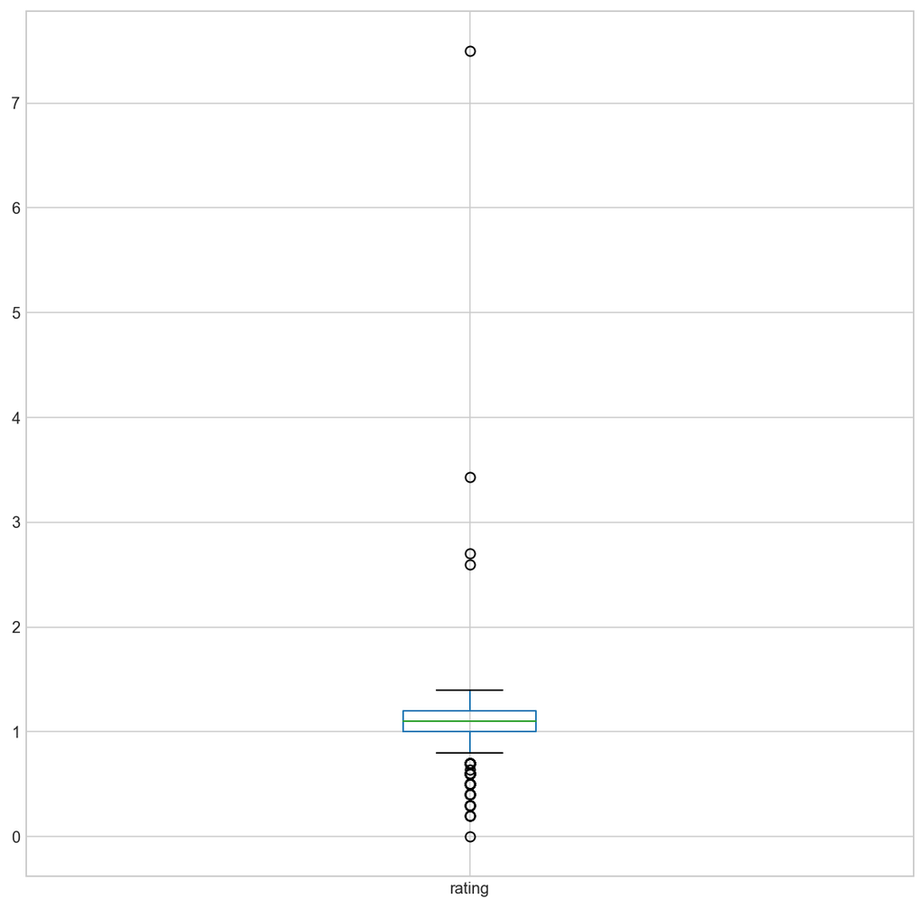

```python
# BoxPlot of Rating
tweet_master_analysis.boxplot(column='rating');
```

As we can see from Plot above, there are a number of records with extremely high ratings, so we may want to see if they fit the `Outliers` definition.

So, I am going to find the `IQR (Interquartile Range)` and see if these points are outliers.

```python
# 1st and 3rd Quantiles
rating_q1 = tweet_master_analysis['rating'].quantile(.25)   #First Quartile
rating_q3 = tweet_master_analysis['rating'].quantile(.75)   #Third Quartile
rating_IQR = rating_q3 - rating_q1   #IQR
```

```python
# Upper Bound
rating_IQR + 1.5 * rating_q3
```

```
1.9999999999999998
```

```python
# Lower Bound.
rating_IQR - 1.5 * rating_q1
```

```
-1.3
```

As we know the rating can not be negative, so the lower bound is 0

So any value `greater than 2` is considered outlier

```python
tweet_master_analysis[tweet_master_analysis['rating'] >= 2]
```

|  | tweet_id | tweet_status | full_text | timestamp | source | expanded_urls | name | dog_stage | rating | retweet_count | favorite_count | in_reply_to_status_id | in_reply_to_user_id | jpg_url | img_num | prediction_1 | p1_confidence | p1_dog | prediction_2 | p2_confidence | p2_dog | prediction_3 | p3_confidence | p3_dog |
| --- | --- | --- | --- | --- | --- | --- | --- | --- | --- | --- | --- | --- | --- | --- | --- | --- | --- | --- | --- | --- | --- | --- | --- | --- |
| 348 | 810984652412424192 | Status(truncated=False, _api=<tweepy.api.API o... | Meet Sam. She smiles 24/7 &amp; secretly aspir... | 2016-12-19 23:06:00 | iPhone | https://www.gofundme.com/sams-smile,https://tw... | Sam | NaN | 3.428571 | 1622 | 5849 | NaN | NaN | https://pbs.twimg.com/media/C0EyPZbXAAAceSc.jpg | 1 | golden_retriever | 0.871342 | True | Tibetan_mastiff | 0.036708 | True | Labrador_retriever | 0.025823 | True |
| 454 | 786709082849828864 | Status(truncated=False, _api=<tweepy.api.API o... | This is Logan, the Chow who lived. He solemnly... | 2016-10-13 23:23:00 | iPhone | https://twitter.com/dog_rates/status/786709082... | Logan | NaN | 7.500000 | 6906 | 19969 | NaN | NaN | https://pbs.twimg.com/media/CurzvFTXgAA2_AP.jpg | 1 | Pomeranian | 0.467321 | True | Persian_cat | 0.122978 | False | chow | 0.102654 | True |
| 499 | 778027034220126208 | Status(truncated=False, _api=<tweepy.api.API o... | This is Sophie. She's a Jubilant Bush Pupper. ... | 2016-09-20 00:24:00 | iPhone | https://twitter.com/dog_rates/status/778027034... | Sophie | NaN | 2.700000 | 1836 | 7195 | NaN | NaN | https://pbs.twimg.com/media/Cswbc2yWcAAVsCJ.jpg | 1 | clumber | 0.946718 | True | cocker_spaniel | 0.015950 | True | Lhasa | 0.006519 | True |
| 1203 | 680494726643068929 | Status(truncated=False, _api=<tweepy.api.API o... | Here we have uncovered an entire battalion of ... | 2015-12-25 21:06:00 | iPhone | https://twitter.com/dog_rates/status/680494726... | NaN | pupper | 2.600000 | 532 | 1840 | NaN | NaN | https://pbs.twimg.com/media/CXGaVxOWAAADjhF.jpg | 1 | kuvasz | 0.438627 | True | Samoyed | 0.111622 | True | Great_Pyrenees | 0.064061 | True |

Let us see these 4 outliers in more detail:

- let us see the tweet's full text and the ratings
- the photo of the dogs will be downloaded and shown

```python
tweet_master_analysis[['full_text', 'rating']][tweet_master_analysis['rating'] >= 2]
```

|  | full_text | rating |
| --- | --- | --- |
| 348 | Meet Sam. She smiles 24/7 &amp; secretly aspir... | 3.428571 |
| 454 | This is Logan, the Chow who lived. He solemnly... | 7.500000 |
| 499 | This is Sophie. She's a Jubilant Bush Pupper. ... | 2.700000 |
| 1203 | Here we have uncovered an entire battalion of ... | 2.600000 |

Now, let's download and display the images

```python
from IPython.display import Image
from IPython.core.display import HTML
```

```python
urls= tweet_master_analysis['jpg_url'][tweet_master_analysis['rating'] >= 2]
urls = urls.tolist()
Image(url=urls[0]) # this dog has a rating of 3.42
```

[figure not shown]

```python
Image(url=urls[1]) # this dog has the highest rating of 7.5
```

[figure not shown]

```python
Image(url=urls[2]) # this dog has a rating of 2.7
```

[figure not shown]

```python
Image(url=urls[3]) # this image has a rating of 2.6
```

[figure not shown]

These images presented very `cute dogs`, so I am not really sure if we cannot give them a very high ratings. So i am not removing the results from the dataset

**Question:** Whats the highest number of retweets? what is the highest number of Favorates (likes).

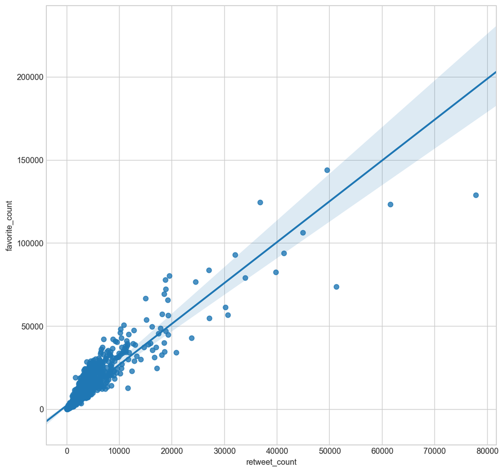

```python
sb.regplot(x='retweet_count', y='favorite_count', data=tweet_master_analysis, scatter=True);
```

From the scatter plot above, we identify a number of very high `retweet counts (greater than 50000)` and `favorite counts of greater than 100000`. So, I am going to filter these results and have a deeper look at them:

```python
tweet_master_analysis[['retweet_count', 'favorite_count', 'rating']].describe()
```

|  | retweet_count | favorite_count | rating |
| --- | --- | --- | --- |
| count | 1686.000000 | 1686.000000 | 1686.000000 |
| mean | 2785.656584 | 9221.742586 | 1.089699 |
| std | 4866.856016 | 13028.289983 | 0.250460 |
| min | 13.000000 | 80.000000 | 0.000000 |
| 25% | 632.250000 | 2115.750000 | 1.000000 |
| 50% | 1403.000000 | 4365.000000 | 1.100000 |
| 75% | 3164.750000 | 11500.000000 | 1.200000 |
| max | 77844.000000 | 144041.000000 | 7.500000 |

```python
# finding the records having more than 50,000 retweet_count and more than 100,000 Favorite count
tweet_master_analysis[(tweet_master_analysis['retweet_count'] >= 50000) | (tweet_master_analysis['favorite_count'] >= 100000)]
```

|  | tweet_id | tweet_status | full_text | timestamp | source | expanded_urls | name | dog_stage | rating | retweet_count | favorite_count | in_reply_to_status_id | in_reply_to_user_id | jpg_url | img_num | prediction_1 | p1_confidence | p1_dog | prediction_2 | p2_confidence | p2_dog | prediction_3 | p3_confidence | p3_dog |
| --- | --- | --- | --- | --- | --- | --- | --- | --- | --- | --- | --- | --- | --- | --- | --- | --- | --- | --- | --- | --- | --- | --- | --- | --- |
| 53 | 879415818425184262 | Status(truncated=False, _api=<tweepy.api.API o... | This is Duddles. He did an attempt. 13/10 some... | 2017-06-26 19:07:00 | iPhone | https://twitter.com/dog_rates/status/879415818... | Duddles | NaN | 1.3 | 44895 | 106488 | NaN | NaN | https://pbs.twimg.com/ext_tw_video_thumb/87941... | 1 | English_springer | 0.383404 | True | Boston_bull | 0.134967 | True | Cardigan | 0.110481 | True |
| 100 | 866450705531457537 | Status(truncated=False, _api=<tweepy.api.API o... | This is Jamesy. He gives a kiss to every other... | 2017-05-22 00:28:00 | iPhone | https://twitter.com/dog_rates/status/866450705... | Jamesy | pupper | 1.3 | 36740 | 124747 | NaN | NaN | https://pbs.twimg.com/media/DAZAUfBXcAAG_Nn.jpg | 2 | French_bulldog | 0.905334 | True | Boston_bull | 0.078060 | True | pug | 0.001771 | True |
| 278 | 822872901745569793 | Status(truncated=False, _api=<tweepy.api.API o... | Here's a super supportive puppo participating ... | 2017-01-21 18:26:00 | iPhone | https://twitter.com/dog_rates/status/822872901... | NaN | puppo | 1.3 | 49485 | 144041 | NaN | NaN | https://pbs.twimg.com/media/C2tugXLXgAArJO4.jpg | 1 | Lakeland_terrier | 0.196015 | True | Labrador_retriever | 0.160329 | True | Irish_terrier | 0.069126 | True |
| 363 | 807106840509214720 | Status(truncated=False, _api=<tweepy.api.API o... | This is Stephan. He just wants to help. 13/10 ... | 2016-12-09 06:17:00 | iPhone | https://twitter.com/dog_rates/status/807106840... | Stephan | NaN | 1.3 | 61545 | 123471 | NaN | NaN | https://pbs.twimg.com/ext_tw_video_thumb/80710... | 1 | Chihuahua | 0.505370 | True | Pomeranian | 0.120358 | True | toy_terrier | 0.077008 | True |
| 691 | 744234799360020481 | Status(truncated=False, _api=<tweepy.api.API o... | Here's a doggo realizing you can stand in a po... | 2016-06-18 18:26:00 | iPhone | https://twitter.com/dog_rates/status/744234799... | NaN | doggo | 1.3 | 77844 | 128947 | NaN | NaN | https://pbs.twimg.com/ext_tw_video_thumb/74423... | 1 | Labrador_retriever | 0.825333 | True | ice_bear | 0.044681 | False | whippet | 0.018442 | True |
| 719 | 739238157791694849 | Status(truncated=False, _api=<tweepy.api.API o... | Here's a doggo blowing bubbles. It's downright... | 2016-06-04 23:31:00 | iPhone | https://twitter.com/dog_rates/status/739238157... | NaN | doggo | 1.3 | 51241 | 73757 | NaN | NaN | https://pbs.twimg.com/ext_tw_video_thumb/73923... | 1 | Eskimo_dog | 0.503372 | True | Siberian_husky | 0.390413 | True | malamute | 0.080901 | True |

```python
condition = (tweet_master_analysis['retweet_count'] >= 50000)\
    | (tweet_master_analysis['favorite_count'] >= 100000)

tweet_master_analysis[['full_text', 'rating', 'retweet_count', 'favorite_count']][condition]
```

|  | full_text | rating | retweet_count | favorite_count |
| --- | --- | --- | --- | --- |
| 53 | This is Duddles. He did an attempt. 13/10 some... | 1.3 | 44895 | 106488 |
| 100 | This is Jamesy. He gives a kiss to every other... | 1.3 | 36740 | 124747 |
| 278 | Here's a super supportive puppo participating ... | 1.3 | 49485 | 144041 |
| 363 | This is Stephan. He just wants to help. 13/10 ... | 1.3 | 61545 | 123471 |
| 691 | Here's a doggo realizing you can stand in a po... | 1.3 | 77844 | 128947 |
| 719 | Here's a doggo blowing bubbles. It's downright... | 1.3 | 51241 | 73757 |

```python
urls = tweet_master_analysis['jpg_url'][condition].tolist()
text = tweet_master_analysis['full_text'][condition].tolist()
retweet_count = tweet_master_analysis['retweet_count'][condition].tolist()
favorite_count = tweet_master_analysis['favorite_count'][condition].tolist()

print(text[0])
print('retweet count:', retweet_count[0])
print('favorite count:', favorite_count[0])
Image(url=urls[0])
```

```
This is Duddles. He did an attempt. 13/10 someone help him (vid by Georgia Felici) https://t.co/UDT7ZkcTgY
retweet count: 44895
favorite count: 106488
```

[figure not shown]

```python
print(text[1])
print('retweet count:', retweet_count[1])
print('favorite count:', favorite_count[1])
Image(url=urls[1])
```

```
This is Jamesy. He gives a kiss to every other pupper he sees on his walk. 13/10 such passion, much tender https://t.co/wk7TfysWHr
retweet count: 36740
favorite count: 124747
```

[figure not shown]

```python
print(text[2])
print('retweet count:', retweet_count[2])
print('favorite count:', favorite_count[2])
Image(url=urls[2])
```

```
Here's a super supportive puppo participating in the Toronto  #WomensMarch today. 13/10 https://t.co/nTz3FtorBc
retweet count: 49485
favorite count: 144041
```

[figure not shown]

```python
print(text[3])
print('retweet count:', retweet_count[3])
print('favorite count:', favorite_count[3])
Image(url=urls[3])
```

```
This is Stephan. He just wants to help. 13/10 such a good boy https://t.co/DkBYaCAg2d
retweet count: 61545
favorite count: 123471
```

[figure not shown]

```python
print(text[4])
print('retweet count:', retweet_count[4])
print('favorite count:', favorite_count[4])
Image(url=urls[4])
```

```
Here's a doggo realizing you can stand in a pool. 13/10 enlightened af (vid by Tina Conrad) https://t.co/7wE9LTEXC4
retweet count: 77844
favorite count: 128947
```

[figure not shown]

**Question:** Does having a `dog_stage` label have any impact on the ratings (or number of retweets and favorites) they receive?

```python
tweet_master_analysis.info()
```

```
<class 'pandas.core.frame.DataFrame'>
Int64Index: 1686 entries, 0 to 1685
Data columns (total 24 columns):
tweet_id                 1686 non-null object
tweet_status             1686 non-null object
full_text                1686 non-null object
timestamp                1686 non-null datetime64[ns]
source                   1686 non-null object
expanded_urls            1686 non-null object
name                     1267 non-null object
dog_stage                293 non-null object
rating                   1686 non-null float64
retweet_count            1686 non-null int64
favorite_count           1686 non-null int64
in_reply_to_status_id    20 non-null object
in_reply_to_user_id      20 non-null object
jpg_url                  1686 non-null object
img_num                  1686 non-null int64
prediction_1             1686 non-null object
p1_confidence            1686 non-null float64
p1_dog                   1686 non-null bool
prediction_2             1686 non-null object
p2_confidence            1686 non-null float64
p2_dog                   1686 non-null bool
prediction_3             1686 non-null object
p3_confidence            1686 non-null float64
p3_dog                   1686 non-null bool
dtypes: bool(3), datetime64[ns](1), float64(4), int64(3), object(13)
memory usage: 374.7+ KB
```

```python
tweet_master_analysis[['dog_stage']].describe()
```

|  | dog_stage |
| --- | --- |
| count | 293 |
| unique | 4 |
| top | pupper |
| freq | 183 |

```python
# we 293 records for which we have a dog_stage label
condition_2 = tweet_master_analysis['dog_stage'].notna()
print( "number records for which we have a dog_stage label:", sum(condition_2))
```

```
number records for which we have a dog_stage label: 293
```

```python
# we 293 records for which we have a dog_stage label
condition_3 = tweet_master_analysis['dog_stage'].isna()
print( "number records for which we have do NOT have a dog_stage label:", sum(condition_3))
```

```
number records for which we have do NOT have a dog_stage label: 1393
```

```python
dog_stage_list = tweet_master_analysis[condition_2]
no_dog_stage_list = tweet_master_analysis[condition_3]
```

```python
dog_stage_list[['rating', 'retweet_count', 'favorite_count']].describe()
```

|  | rating | retweet_count | favorite_count |
| --- | --- | --- | --- |
| count | 293.000000 | 293.000000 | 293.000000 |
| mean | 1.126280 | 3548.972696 | 11111.419795 |
| std | 0.171493 | 7130.012859 | 16815.259802 |
| min | 0.500000 | 90.000000 | 337.000000 |
| 25% | 1.000000 | 883.000000 | 2720.000000 |
| 50% | 1.100000 | 1573.000000 | 5283.000000 |
| 75% | 1.200000 | 3427.000000 | 12397.000000 |
| max | 2.600000 | 77844.000000 | 144041.000000 |

```python
no_dog_stage_list[['rating', 'retweet_count', 'favorite_count']].describe()
```

|  | rating | retweet_count | favorite_count |
| --- | --- | --- | --- |
| count | 1393.000000 | 1393.000000 | 1393.000000 |
| mean | 1.082005 | 2625.102656 | 8824.272793 |
| std | 0.263484 | 4226.043114 | 12051.599153 |
| min | 0.000000 | 13.000000 | 80.000000 |
| 25% | 1.000000 | 579.000000 | 1851.000000 |
| 50% | 1.100000 | 1359.000000 | 4142.000000 |
| 75% | 1.200000 | 3088.000000 | 11293.000000 |
| max | 7.500000 | 61545.000000 | 123471.000000 |

To check whether having a `dog_stage` label have any positive or negative (non-directional) impact on retweet_count, or favorite_count), we test the null hypothesis below:

The `null hypothesis` is that there is no statistically significant difference between the population mean of the retweet_count of the records with a dog stage label and that of the rest of the data frames(not having any dog stage label):

$$\large H_0: \mu_D = \mu_N$$

So, the `alternative hypothesis` is:

- The population mean of the records with a dog_stage label is significantly different than that of the rest with no dog stage labels: $$\large H_a: \mu_D \neq \mu_N$$

Where:

- $\large H_0$: the Null Hypothesis;
- $\large H_a$: the Alternative Hypothesis;
- $\large \mu_D$: Dog stage label;
- $\large \mu_N$: No dog stage label;

## The proposed Statistical Test

Knowing our null and the alternative hypothesis, we need a rigorous statistical test to decide whether we reject or retain the null hypothesis. We need a Two Samples test, a comparison of data from one sample to data from a different sample to determine if the two populations they came from are the same.

Here, we use t-Test for Independent Means. According to this [link](http://www.psychology.emory.edu/clinical/bliwise/Tutorials/TOM/meanstests/assump.htm) the assumptions for a t-test for Independent Means are listed below:

- Interval or ratio scale of measurement (approximately interval)
- Random sampling from a defined population
- Samples are independent; no overlap between group members
- Scores are normally distributed in the population
- Population variances are equal

```python
print ('Standard Deviation of retweet_count for no_dog_stage_list set:',
       no_dog_stage_list.retweet_count.std())

print ('Standard Deviation of retweet_count for dog_stage_list set:',
       dog_stage_list.retweet_count.std())

print ('Population Mean of retweet_count for no_dog_stage_list set:',
       no_dog_stage_list.retweet_count.mean())

print ('Population Mean of retweet_count for dog_stage_list set:',
       dog_stage_list.retweet_count.mean())
```

```
Standard Deviation of retweet_count for no_dog_stage_list set: 4226.043113625143
Standard Deviation of retweet_count for dog_stage_list set: 7130.012859452941
Population Mean of retweet_count for no_dog_stage_list set: 2625.102656137832
Population Mean of retweet_count for dog_stage_list set: 3548.972696245734
```

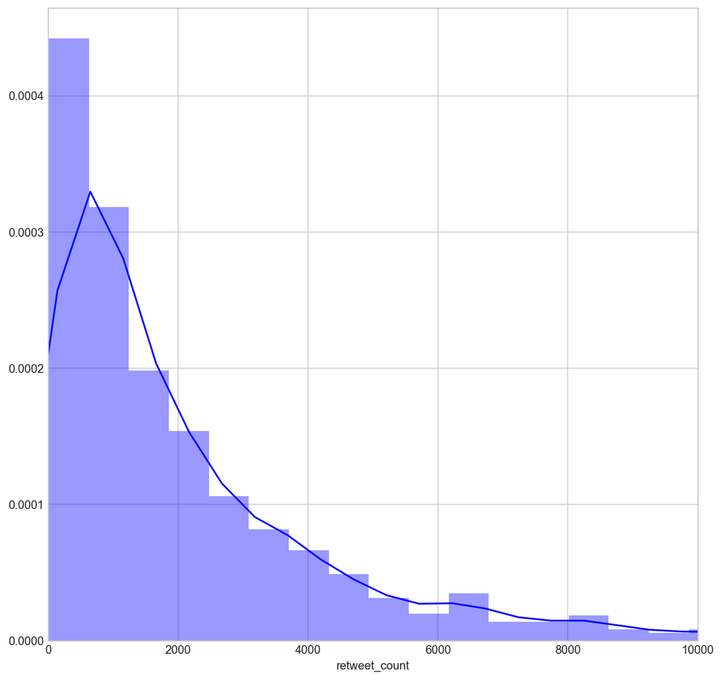

```python
my_plot = sb.distplot(no_dog_stage_list.retweet_count, bins=100, color='blue')

axes = my_plot.axes
axes.set_xlim(0,10000);
```

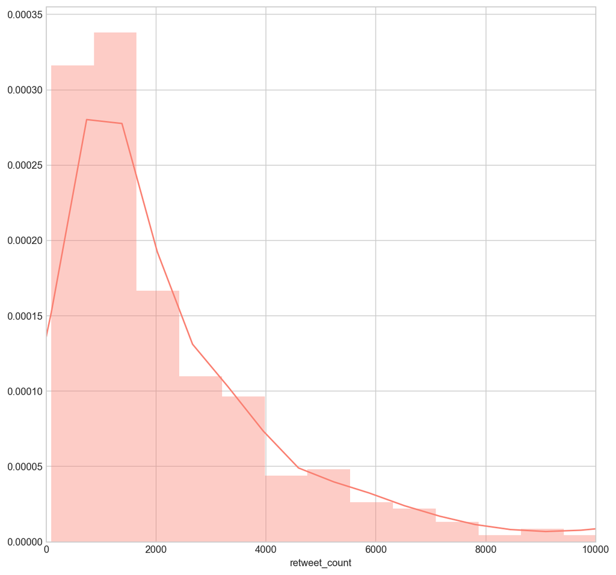

```python
my_plot2 = sb.distplot(dog_stage_list.retweet_count, bins=100, color='salmon')

axes = my_plot2.axes
axes.set_xlim(0,10000);
```

```python
import scipy.stats as stats

statistic,pvalue = stats.ttest_ind(dog_stage_list.retweet_count,
                                   no_dog_stage_list.retweet_count, nan_policy='omit')
print ('pvalue = ', pvalue)
```

```
pvalue =  0.003115986588672567
```

So, it shows that we can `reject the null hypothesis` because the p-value is less than 0.05 and indeed it is far below that number. So, **statistically there is a significant difference between the number of retweets based on whether or not the dog has a dog stage label.**

I believe this finding is significant, because it might bring a very interesting insight to WeRateDogs, they know, if they could make sure that they assign a dog_stage to the dog for which they are going to post a status, it may generate more retweets and likes!

**Question:** To examine different trends over time (`timestamp`)

```python
tweet_master_analysis.info()
```

```
<class 'pandas.core.frame.DataFrame'>
Int64Index: 1686 entries, 0 to 1685
Data columns (total 24 columns):
tweet_id                 1686 non-null object
tweet_status             1686 non-null object
full_text                1686 non-null object
timestamp                1686 non-null datetime64[ns]
source                   1686 non-null object
expanded_urls            1686 non-null object
name                     1267 non-null object
dog_stage                293 non-null object
rating                   1686 non-null float64
retweet_count            1686 non-null int64
favorite_count           1686 non-null int64
in_reply_to_status_id    20 non-null object
in_reply_to_user_id      20 non-null object
jpg_url                  1686 non-null object
img_num                  1686 non-null int64
prediction_1             1686 non-null object
p1_confidence            1686 non-null float64
p1_dog                   1686 non-null bool
prediction_2             1686 non-null object
p2_confidence            1686 non-null float64
p2_dog                   1686 non-null bool
prediction_3             1686 non-null object
p3_confidence            1686 non-null float64
p3_dog                   1686 non-null bool
dtypes: bool(3), datetime64[ns](1), float64(4), int64(3), object(13)
memory usage: 374.7+ KB
```

```python
type(tweet_master_analysis['timestamp'])
```

```
pandas.core.series.Series
```

First I am going to create a Pandas DatetimeIndex based on `timestamp` column.

```python
dates = pd.DatetimeIndex(tweet_master_analysis['timestamp'])
```

```python
dates
```

```
DatetimeIndex(['2017-08-01 00:17:00', '2017-07-31 00:18:00', '2017-07-30 15:58:00', '2017-07-29 16:00:00', '2017-07-29 00:08:00', '2017-07-28 16:27:00', '2017-07-28 00:22:00', '2017-07-27 16:25:00', '2017-07-26 15:59:00', '2017-07-26 00:31:00',
               ...
               '2015-11-16 01:22:00', '2015-11-16 01:01:00', '2015-11-16 00:55:00', '2015-11-16 00:49:00', '2015-11-16 00:30:00', '2015-11-16 00:24:00', '2015-11-16 00:04:00', '2015-11-15 23:21:00', '2015-11-15 23:05:00', '2015-11-15 22:32:00'], dtype='datetime64[ns]', name='timestamp', length=1686,…
```

```python
dates.shape
```

```
(1686,)
```

So, now let's create a time series, dates from the above (*dates* Variable) and *retweet count* values will be our values.

```python
ts = np.asarray(tweet_master_analysis[['retweet_count','favorite_count', 'rating']])
ts
```

```
array([[6.3550e+03, 3.3390e+04, 1.3000e+00],
       [4.2200e+03, 2.5168e+04, 1.2000e+00],
       [8.7680e+03, 4.2347e+04, 1.3000e+00],
       ...,
       [4.5000e+01, 1.2500e+02, 9.0000e-01],
       [4.7000e+01, 1.3100e+02, 7.0000e-01],
       [5.1900e+02, 2.5260e+03, 8.0000e-01]])
```

```python
ts.shape
```

```
(1686, 3)
```

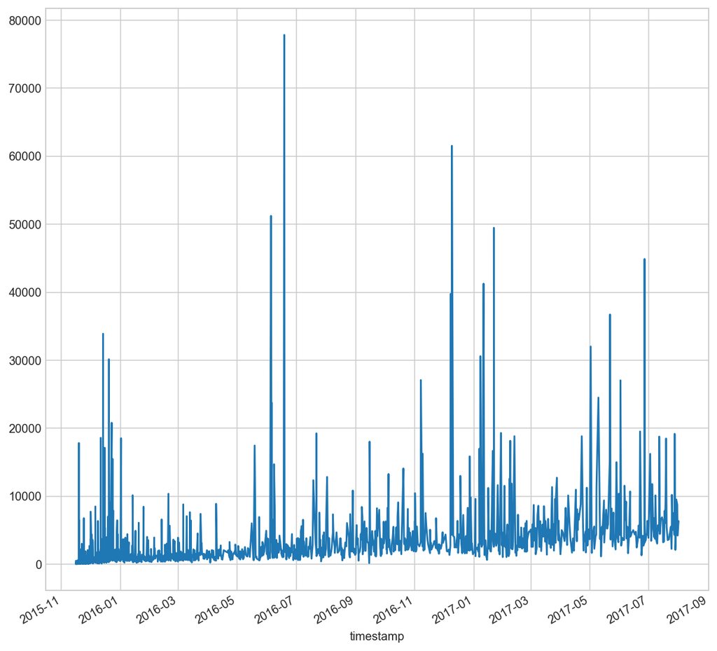

```python
# Retweet Count over time
TS = Series(ts[:,0], index=dates)

TS.plot();
```

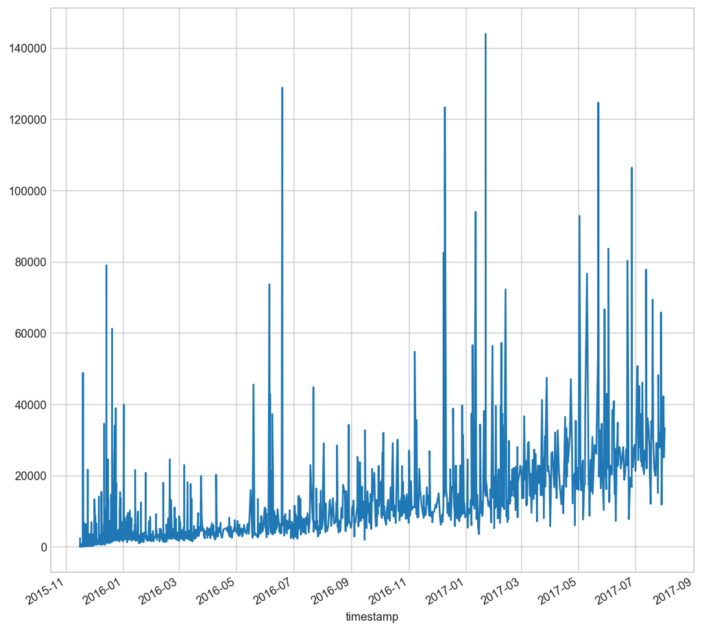

```python
# favorite Count over time
TS = Series(ts[:,1], index=dates)

TS.plot();
```

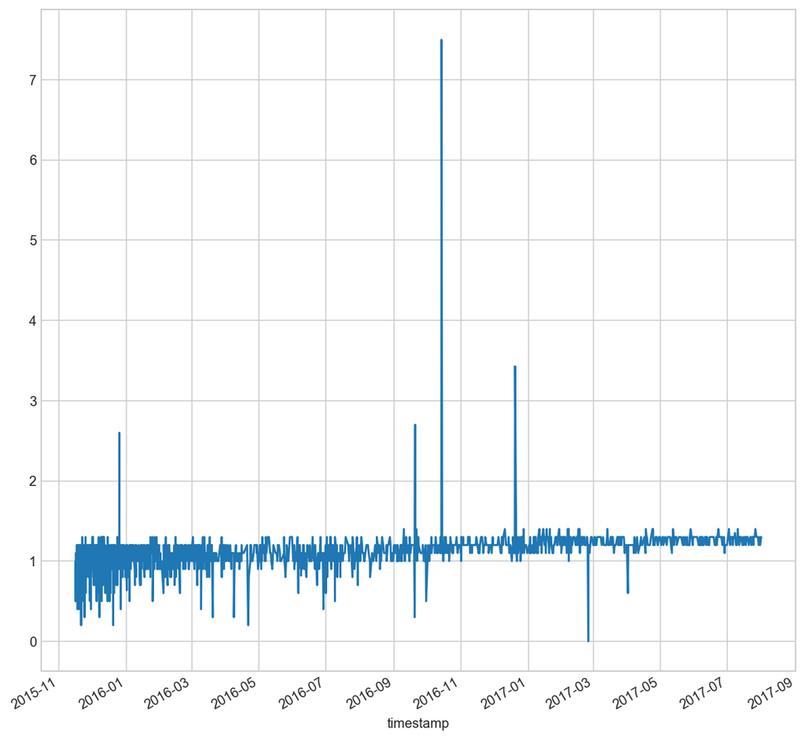

```python
# rating Count over time
TS = Series(ts[:,2], index=dates)

TS.plot();
```